# Analisis Data Kelompok 6

# Analisis Sisaan

Model terbaik hasil identifikasi kemudian dicek asumsi sisaannya. Sisaan model ARIMA harus memenuhi asumsi normalitas, kebebasan sisaan, dan kehomogenan ragam. Diagnostik model dilakukan secara eksplorasi dan uji formal.

## Eksplorasi Sisaan

```r
sisaan <- train.ts-model3$fitted
sisaan
```

```
## Time Series:
## Start = 1
## End = 430
## Frequency = 1
##   [1]  0.026299983  1.048501265 -0.494253336 -0.254652759  0.873286206
##   [6]  2.439437455  1.258359576 -0.358385932  1.191601351  1.743234777
##  [11] -0.240569972  0.628431151  0.555085798  0.373880831  0.960145251
##  [16] -0.280530109 -1.218967195 -0.472710967 -0.703323511  0.520129403
##  [21]  0.081058808  0.665535786 -0.188598051  0.539303146 -1.588904514
##  [26] -0.129888256 -0.512630894 -2.456674652 -0.268928192  0.637809313
##  [31] -0.187430657 -0.802639538 -0.178457278 -0.764841902  0.488736924
##  [36]  0.784759921  1.213376347 -0.576760542 -0.679264375 -0.028327093
##  [41]  0.293982680 -0.327522617 -2.614405732  1.230826905 -0.205141399
##  [46]  0.651187822 -0.574524965 -0.291377861  0.410553498 -0.006991965
##  [51]  0.043823827  0.564940439 -0.403254480 -0.493633914 -1.369406053
```

[output cut: 75 more lines]

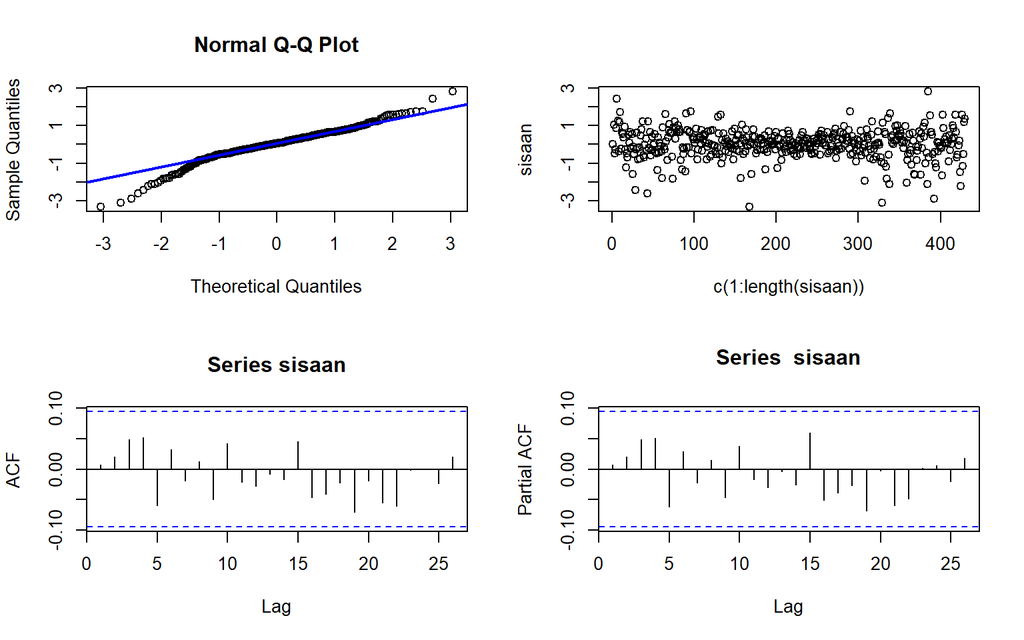

```r
par(mfrow=c(2,2))
qqnorm(sisaan)
qqline(sisaan, col = "blue", lwd = 2)
plot(c(1:length(sisaan)),sisaan)
acf(sisaan)
pacf(sisaan)
```

```r
par(mfrow = c(1,1))
```

Berdasarkan plot kuantil-kuantil normal, secara eksplorasi ditunjukkan sisaan tidak menyebar normal ditandai dengan titik-titik di ujung garis yang cenderung tidak mengikuti garis $45^{\circ}$. Kemudian dapat dilihat juga lebar pita sisaan yang cenderung tidak sama menandakan bahwa sisaan memiliki ragam yang heterogen. Plot ACF dan PACF sisaan ARIMA(0,1,3) juga tidak signifikan pada 20 lag awal yang menandakan saling bebas. Kondisi ini akan diuji lebih lanjut dengan uji formal.

## Uji Formal

### Normalitas Sisaan

Selain dengan eksplorasi, asumsi tersebut dapat diuji menggunakan uji formal. Pada tahapan ini uji formal yang digunakan untuk normalitas adalah uji Kolmogorov-Smirnov (KS), uji Shapiro-Wilk, dan uji Anderson-Darling. Hipotesis uji yang digunakan adalah sebagai berikut.

$H_0$ : Sisaan menyebar normal

$H_1$ : Sisaan tidak menyebar normal

```r
#1) Sisaan Menyebar Normal
ks.test(sisaan,"pnorm")
```

```
##
##  Asymptotic one-sample Kolmogorov-Smirnov test
##
## data:  sisaan
## D = 0.14019, p-value = 9.134e-08
## alternative hypothesis: two-sided
```

```r
#tak tolak H0 > sisaan menyebar normal
shapiro.test(sisaan)
```

```
##
##  Shapiro-Wilk normality test
##
## data:  sisaan
## W = 0.95809, p-value = 1.026e-09
```

```r
nortest::ad.test(sisaan)
```

```
##
##  Anderson-Darling normality test
##
## data:  sisaan
## A = 4.31, p-value = 1.017e-10
```

Berdasarkan ketiga uji tersebut, didapat *p-value* kurang dari taraf nyata 5% sehingga tolak $H_0$ dan menandakan bahwa sisaan tidak menyebar normal. Hal ini sesuai dengan hasil eksplorasi menggunakan plot kuantil-kuantil normal.

### Sisaan Saling Bebas

Selanjutnya akan dilakukan uji formal untuk kebebasan sisaan menggunakan uji Ljung-Box. Hipotesis yang digunakan adalah sebagai berikut.

$H_0$ : Sisaan saling bebas

$H_1$ : Sisaan tidak tidak saling bebas

```r
#2) Sisaan saling bebas/tidak ada autokorelasi
Box.test(sisaan, type = "Ljung")  #tak tolak H0 > sisaan saling bebas
```

```
##
##  Box-Ljung test
##
## data:  sisaan
## X-squared = 0.02022, df = 1, p-value = 0.8869
```

### Kehomogenan Ragam

Hipotesis yang digunakan untuk uji kehomogenan ragam adalah sebagai berikut.

$H_0$ : Ragam sisaan homogen

$H_1$ : Ragam sisaan tidak homogen

```r
#3) Sisaan homogen
Box.test((sisaan)^2, type = "Ljung")  #tak tolak H0 > sisaan homogen
```

```
##
##  Box-Ljung test
##
## data:  (sisaan)^2
## X-squared = 5.4326, df = 1, p-value = 0.01976
```

### Nilai Tengah Sisaan Sama dengan Nol

Terakhir, dengan uji-t, akan dicek apakah nilai tengah sisaan sama dengan nol. Hipotesis yang diujikan sebagai berikut.

$H_0$ : nilai tengah sisaan sama dengan 0

$H_1$ : nilai tengah sisaan tidak sama dengan 0

```r
#4) Nilai tengah sisaan sama dengan nol
t.test(sisaan, mu = 0, conf.level = 0.95)  #tak tolak h0 > nilai tengah sisaan sama dengan 0
```

```
##
##  One Sample t-test
##
## data:  sisaan
## t = 0.58288, df = 429, p-value = 0.5603
## alternative hypothesis: true mean is not equal to 0
## 95 percent confidence interval:
##  -0.05207965  0.09599055
## sample estimates:
##  mean of x
## 0.02195545
```

Berdasarkan uji-ttersebut, didapat *p-value* sebesar 0.5603 yang lebih besar dari taraf nyata 5% sehingga tak tolak $H_0$ dan menandakan bahwa nilai tengah sisaan sama dengan nol. Hal ini berbeda dengan eksplorasi.

# ARCH-Garch

## Identifikasi efek arch

```r
library(FinTS)
for (i in 1:15) {
  ArchTest <- ArchTest(sisaan, lags=i, demean=TRUE)
  cat("P Value LM Test lag ke", i,"adalah" , ArchTest$p.value, "\n") }
```

```
## P Value LM Test lag ke 1 adalah 0.02069812
## P Value LM Test lag ke 2 adalah 0.06779885
## P Value LM Test lag ke 3 adalah 0.04571856
## P Value LM Test lag ke 4 adalah 0.0936324
## P Value LM Test lag ke 5 adalah 0.158517
## P Value LM Test lag ke 6 adalah 0.1919356
## P Value LM Test lag ke 7 adalah 0.07936624
## P Value LM Test lag ke 8 adalah 0.1146594
## P Value LM Test lag ke 9 adalah 0.05372865
## P Value LM Test lag ke 10 adalah 0.03267323
## P Value LM Test lag ke 11 adalah 0.04633769
## P Value LM Test lag ke 12 adalah 0.05167029
## P Value LM Test lag ke 13 adalah 0.05741495
## P Value LM Test lag ke 14 adalah 0.03910634
## P Value LM Test lag ke 15 adalah 0.04718347
```

```r
archspec <- ugarchspec(
  variance.model=list(model="sGARCH",
                      garchOrder=c(0,1)),
mean.model=list(armaOrder=c(0,3)))
archFit11 <- ugarchfit(spec=archspec, data=train.diff)
archFit11
```

```
##
## *---------------------------------*
## *          GARCH Model Fit        *
## *---------------------------------*
##
## Conditional Variance Dynamics
## -----------------------------------
## GARCH Model  : sGARCH(0,1)
## Mean Model   : ARFIMA(0,0,3)
## Distribution : norm
##
## Optimal Parameters
## ------------------------------------
##        Estimate  Std. Error   t value Pr(>|t|)
## mu     0.004216    0.009183   0.45914 0.646133
## ma1   -0.494133    0.048524 -10.18324 0.000000
## ma2   -0.177680    0.052525  -3.38278 0.000718
## ma3   -0.088497    0.047040  -1.88133 0.059926
## omega  0.002360    0.000681   3.46629 0.000528
## beta1  0.996190    0.001271 784.01874 0.000000
##
## Robust Standard Errors:
##        Estimate  Std. Error    t value Pr(>|t|)
## mu     0.004216    0.008847    0.47657 0.633668
## ma1   -0.494133    0.055459   -8.90984 0.000000
## ma2   -0.177680    0.053685   -3.30970 0.000934
## ma3   -0.088497    0.058486   -1.51315 0.130243
## omega  0.002360    0.000795    2.96740 0.003003
## beta1  0.996190    0.000471 2113.67781 0.000000
##
## LogLikelihood : -505.4582
##
## Information Criteria
## ------------------------------------
##
## Akaike       2.3844
## Bayes        2.4412
## Shibata      2.3840
## Hannan-Quinn 2.4069
##
```

[output cut: 43 more lines]

```
## Negative Sign Bias  2.9139 0.0037582 ***
## Positive Sign Bias  0.9495 0.3429266
## Joint Effect       17.9074 0.0004596 ***
##
##
## Adjusted Pearson Goodness-of-Fit Test:
## ------------------------------------
##   group statistic p-value(g-1)
## 1    20     38.93    4.516e-03
## 2    30     58.34    9.884e-04
## 3    40     80.74    9.731e-05
## 4    50     90.00    3.232e-04
##
##
## Elapsed time : 0.2287638
```

# Peramalan

Peramalan dilakukan menggunakan fungsi `forecast()` . Contoh peramalan berikut ini dilakukan untuk 71 hari ke depan.

```r
ramalan <- forecast::forecast(model3, h = 71)
ramalan
```

```
##     Point Forecast    Lo 80    Hi 80    Lo 95    Hi 95
## 431       29.32615 28.32124 30.33107 27.78927 30.86303
## 432       28.93688 27.81858 30.05517 27.22659 30.64716
## 433       28.78975 27.63232 29.94718 27.01961 30.55989
## 434       28.78975 27.61665 29.96286 26.99564 30.58386
## 435       28.78975 27.60118 29.97832 26.97199 30.60751
## 436       28.78975 27.58592 29.99359 26.94865 30.63086
## 437       28.78975 27.57084 30.00866 26.92559 30.65391
## 438       28.78975 27.55595 30.02355 26.90282 30.67669
## 439       28.78975 27.54124 30.03826 26.88032 30.69919
## 440       28.78975 27.52670 30.05281 26.85808 30.72143
## 441       28.78975 27.51232 30.06718 26.83609 30.74341
## 442       28.78975 27.49810 30.08140 26.81435 30.76516
## 443       28.78975 27.48404 30.09546 26.79284 30.78666
## 444       28.78975 27.47013 30.10937 26.77157 30.80794
```

[output cut: 57 more lines]

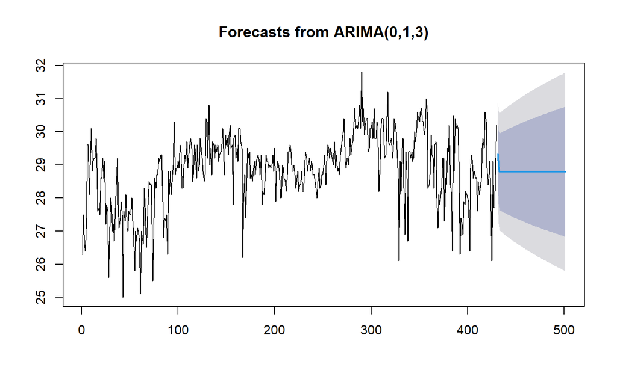

```r
data.ramalan <- ramalan$mean
plot(ramalan)
```

Berdasarkan hasil plot ramalan di atas, dapat dilihat bahwa ramalan ARIMA(0,1,3) cenderung stabil hingga akhir periode. Selanjutnya, dapat dicari nilai akurasi antara hasil ramalan dengan data uji sebagai berikut.

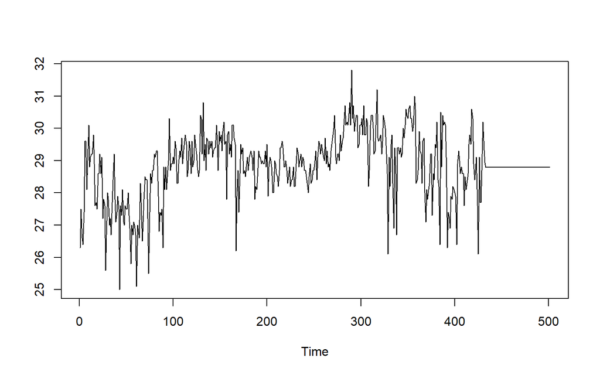

```r
pt_1 <- train.ts[430] #nilai akhir data latih
hasil.forc.Diff <- ts(c(pt_1,data.ramalan), start = 430)
ts.plot(train.ts,hasil.forc.Diff)
```

```r
perbandingan<-matrix(data=c(head(test.ts, n=71), hasil.forc.Diff[-1]),
                     nrow = 71, ncol = 2)
colnames(perbandingan)<-c("Aktual","Hasil Forecast")
perbandingan
```

```
##       Aktual Hasil Forecast
##  [1,]   29.6       29.32615
##  [2,]   29.7       28.93688
##  [3,]   29.2       28.78975
##  [4,]   25.4       28.78975
##  [5,]   27.9       28.78975
##  [6,]   27.9       28.78975
##  [7,]   28.8       28.78975
##  [8,]   28.2       28.78975
##  [9,]   27.2       28.78975
## [10,]   27.4       28.78975
## [11,]   26.0       28.78975
## [12,]   27.0       28.78975
## [13,]   29.0       28.78975
## [14,]   30.2       28.78975
```

[output cut: 57 more lines]

```r
accuracy(ts(hasil.forc.Diff[-1]), head(test.ts, n=71))
```

```
##                 ME     RMSE      MAE      MPE     MAPE      ACF1 Theil's U
## Test set 0.6738607 1.422354 1.190657 2.101143 4.031578 0.5363407  1.147216
```

## RAMALARCH

```r
forc = ugarchforecast(archFit11, data = suhu, n.ahead = 71,n.roll = 0)
print(forc)
```

```
##
## *------------------------------------*
## *       GARCH Model Forecast         *
## *------------------------------------*
## Model: sGARCH
## Horizon: 71
## Roll Steps: 0
## Out of Sample: 0
##
## 0-roll forecast [T0=430-01-01]:
##         Series  Sigma
## T+1  -0.862434 0.7869
## T+2  -0.352131 0.7869
## T+3  -0.120208 0.7869
## T+4   0.004216 0.7869
## T+5   0.004216 0.7869
## T+6   0.004216 0.7869
## T+7   0.004216 0.7869
## T+8   0.004216 0.7869
## T+9   0.004216 0.7869
## T+10  0.004216 0.7869
## T+11  0.004216 0.7869
## T+12  0.004216 0.7869
## T+13  0.004216 0.7869
## T+14  0.004216 0.7869
## T+15  0.004216 0.7869
## T+16  0.004216 0.7869
## T+17  0.004216 0.7869
## T+18  0.004216 0.7869
## T+19  0.004216 0.7869
## T+20  0.004216 0.7869
## T+21  0.004216 0.7869
## T+22  0.004216 0.7869
## T+23  0.004216 0.7869
## T+24  0.004216 0.7869
## T+25  0.004216 0.7869
## T+26  0.004216 0.7869
## T+27  0.004216 0.7869
## T+28  0.004216 0.7869
## T+29  0.004216 0.7869
```

[output cut: 27 more lines]

```
## T+57  0.004216 0.7869
## T+58  0.004216 0.7869
## T+59  0.004216 0.7869
## T+60  0.004216 0.7869
## T+61  0.004216 0.7869
## T+62  0.004216 0.7869
## T+63  0.004216 0.7869
## T+64  0.004216 0.7869
## T+65  0.004216 0.7869
## T+66  0.004216 0.7869
## T+67  0.004216 0.7869
## T+68  0.004216 0.7869
## T+69  0.004216 0.7869
## T+70  0.004216 0.7869
## T+71  0.004216 0.7869
```

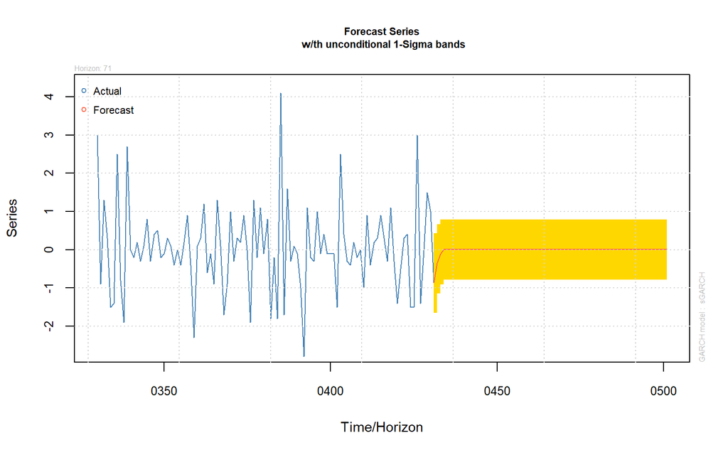

```r
plot(forc, which= 1)
```

```r
pt_1 <- train.ts[430] #nilai akhir data latih
hasil.forc.Diff <- forc@forecast$seriesFor[,1]
hasil <- diffinv(hasil.forc.Diff, differences = 1) + pt_1
perbandingan <- data.frame("Aktual"= test.ts,
                           "Ramalan" = hasil[-1])
perbandingan
```

```
##    Aktual  Ramalan
## 1    29.6 29.33757
## 2    29.7 28.98543
## 3    29.2 28.86523
## 4    25.4 28.86944
## 5    27.9 28.87366
## 6    27.9 28.87788
## 7    28.8 28.88209
## 8    28.2 28.88631
## 9    27.2 28.89053
## 10   27.4 28.89474
## 11   26.0 28.89896
## 12   27.0 28.90317
## 13   29.0 28.90739
## 14   30.2 28.91161
```

[output cut: 57 more lines]

```r
accuracy(ts(hasil[-1]), head(test.ts, n=71))
```

```
##                 ME     RMSE      MAE      MPE     MAPE      ACF1 Theil's U
## Test set 0.4603472 1.282804 1.056961 1.383598 3.599082 0.4949936  1.041355
```